# Outline

## Outline

1. Input data
   - generation steps
   - regressors and response
2. Model selection
   - standard in-sample metrics for models comparison
   - linear model (“all models are wrong, but some are useful”)
3. Trees
   - boosting (BDT), bagging (Random Forest)
   - predictors' importance
   - residuals and turn-on curves
   - ROCs and efficiency vs. rate curves

## Training data

- [Generated](https://github.com/kkotov/emtfPtRegression/blob/master/mc.txt) 300\(k\) di-muons uniformly in \(0.9 < |\eta| < 2.4\) and \(0 < p_T < 100~GeV\)
- Re-emulated EMTF with Jia Fu's new code [1](https://github.com/jiafulow/DataFormatsSep2016),[2](https://github.com/jiafulow/L1TriggerSep2016) (default switches)
- Produced csv file with my [ntuplizer](https://github.com/kkotov/framework)

The 20 predictors (no input from RPC system yet):

| type | trait | measurements with 4 stations | allowed values |
| --- | --- | --- | --- |
| \(\Delta\phi\) | continuous | 1-2, 1-3, 1-4, 2-3, 2-4, 3-4 | [-512 - +512] |
| \(\Delta\theta\) | continuous | 1-2, 1-3, 1-4, 2-3, 2-4, 3-4 | [-7 - +7] |
| CLCT_Pattern | categorical | 1, 2, 3, 4 | [2,3,4,5,6,7,8,9,10] |
| FrontRear | categorical | 1, 2, 3, 4 | [0,1] |

Response variable: \(1/p_T\) to rank up accuracy of low \(p_T\) regression

## Simplest performance metrics

- Residual sum of squares (\(RSS\)) and Root Mean Squared Error (\(RMSE\)):

\[ RSS = \Sigma^N_{i=0} (y_i - \hat{y}_i)^2, RMSE = \sqrt{\frac{1}{N}\Sigma^N_{i=0}(y_i - \hat{y}_i)^2} \]

- Fraction of variance explained (\(R^2\)): \[ R^2 = 1 - \frac{RSS}{TSS}, TSS = \Sigma^N_{i=0} (y_i - \bar{y}_i)^2 \]
  - 0 - no better than the baseline \(\hat{y} = \bar{y}\) model, 1 - ideal model
  - for simple linear regression \(y \sim x\), \(R\) is just a correlation between \(x\) and \(y\)

The more predictors (freedoms) one uses to build a model the better it fits training data

Metrics above will always favor more complex models fitting in-sample noise

## In-sample performance and model complexity

- \(F\)-statistics (lack-of-fit sum-of-squares over pure error sum-of-squares): \[ F = \frac{(RSS_0-RSS_1)/(p_1-p_0)}{RSS_1/(N-p_1-1)} \sim F_{p_1-p_0,N-p_1-1} \rightarrow \chi^2_{p_1-p_0}/(p_1-p_0) \]
  - tests if model with \(p_1\) parameters is better than nested model with \(p_0\) parameters
  - \(z\)-score of a coefficient is equivalent to \(F\)-statistics for dropping this coefficient out
  - unlike the \(z\)-score, \(F\)-statistics can also handle categorical predictors
- Adjusted \(R^2\) (regular \(R^2\) penalized for model complexity):

\[ Adjusted~R^2 = 1 - \frac{RSS/(N-p-1)}{TSS/(N-1)} \]

- Mallow's \(C_p = \frac{1}{N}(RSS + 2d\hat{\sigma}_{\epsilon(y)}^2)\), (\(d < p\) - number of predictors used)
  - second term (form for linear model) compensates against in-sample overfitting
  - \(C_p\) is commonly used for best subset and stepwise model selections

## Ranking predictors for linear model

```
Analysis of Variance Table

Model 1: 1/pt ~ abs(dPhi12)
Model 2: 1/pt ~ abs(dPhi12) + abs(dPhi23)
Model 3: 1/pt ~ abs(dPhi12) + abs(dPhi23) + abs(dPhi34)
Model 4: 1/pt ~ abs(dPhi12) + abs(dPhi23) + abs(dPhi34) + abs(dPhi13)
Model 5: 1/pt ~ abs(dPhi12) + abs(dPhi23) + abs(dPhi34) + abs(dPhi13) +
    abs(dPhi14)
Model 6: 1/pt ~ abs(dPhi12) + abs(dPhi23) + abs(dPhi34) + abs(dPhi13) +
    abs(dPhi14) + abs(dPhi24)
  Res.Df    RSS Df Sum of Sq         F    Pr(>F)
1 311344 169.88
2 311343 169.87  1    0.0107    23.072 1.562e-06 ***
3 311342 161.19  1    8.6854 18758.408 < 2.2e-16 ***
4 311341 156.31  1    4.8794 10538.338 < 2.2e-16 ***
5 311340 156.21  1    0.0960   207.349 < 2.2e-16 ***
6 311339 144.16  1   12.0570 26040.235 < 2.2e-16 ***
---
Signif. codes:  0 '***' 0.001 '**' 0.01 '*' 0.05 '.' 0.1 ' ' 1
```

## Visualizing some of the linear fits

Linear fit does not do well for dPhi23 (also seen as low \(F\)-statistics above):

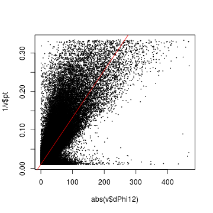

```r
plot(abs(v$dPhi12), 1/v$pt, cex=.1)
abline(lm(1/pt~abs(dPhi12),v),col="red")
```

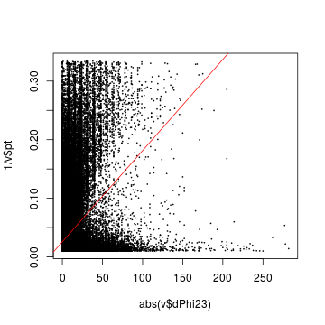

```r
plot(abs(v$dPhi23), 1/v$pt, cex=.1)
abline(lm(1/pt~abs(dPhi23),v),col="red")
```

## Ranking predictors with lasso

Lasso calculates model parameters \(\beta\) by minimizing regularized loss \(RSS + \lambda\Sigma_{i=1}^p|\beta_i|\)

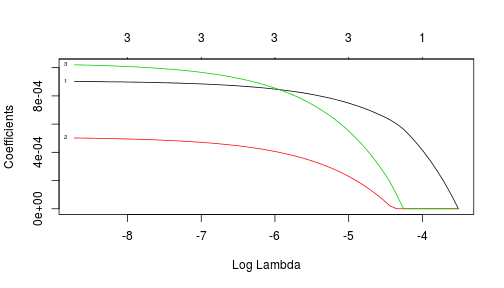

```r
x = model.matrix(1/pt ~ abs(dPhi12) + abs(dPhi23) + abs(dPhi34) - 1, v)
plot( glmnet(x, 1/d$pt), xvar="lambda", label=T )
```

dPhi12 (#1) is the last suppressed with growing \(\lambda\), while dPhi23 (#2) is sacrificed first

## Choosing best predictors in linear model

Best subset selection “switches on” (shades of gray) predictors as follows:

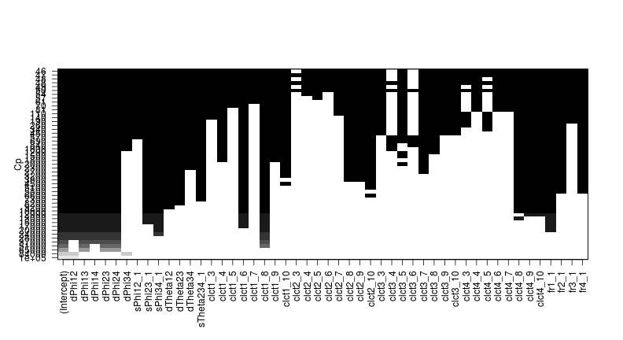

The most important predictors in a linear model (of my choice) are dPhi, clct1 and fr1

## Tree-based methods

Simple decision tree: just crude partitioning of the predictor space

Boosting (in BDT):

- iteratively fit \((x,r)\), where residuals \(r_0 = y\) and \(r_k = r_{k-1} - \lambda\hat{f}_{k-1}(x)\)
- output of the boosted model with complex decision boundary: \(\hat{f}(x) = \Sigma_{k=1}^K\lambda \hat{f}_k(x)\)

Bagging or Bootstrap aggregation (in Random Forest or RF used through the rest of this study):

- resample input data multiple times leaving a part of randomly chosen events out
- each time fit a collection of small \(mtry\)-sized trees of randomly chosen predictors
- average these (largely *de-correlated*) noisy but unbiased models to reduce variance
- along the way construct out-of-bag (OOB) error estimate with the left out data

Cross-validation (repetitive testing of a model on data never seen before) is part of RF training

## Selecting best predictors for trees

Absolute predictor's importance = difference in predictive measure (e.g. MSE) with the original training dataset and a dataset with this predictor being randomly 'permuted':

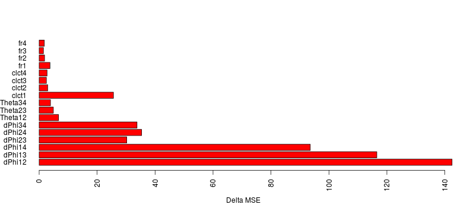

dPhi predictors are the winners (with the first station been most important) followed by clct1

## Input compression

I need to fit the model above into our 2Gb Look Up Table addressed with just 30 bits

Required transformations:

- use mode [compression](https://github.com/kkotov/emtfPtRegression/blob/master/modeCoding.txt): “heaviest” 4-station measurement is indexed with one bit
- make all predictors unsigned; “saturate” them to max value when they are too big
- assign a bit per relevant relative sign (e.g. sign(\(\Delta\phi_{2-3}*\Delta\phi_{1-2}\)) \(\equiv\) S(\(\Delta\phi_{2-3/1-2}\)))
- strip non-informative CLCT levels (linear model suggest clct=6,8,10 most important ones)

Following (potentially sub-optimal) scheme, inspired by [current code](https://github.com/jiafulow/L1TriggerSep2016/blob/master/L1TMuonEndCap/src/EMTFPtAssignmentEngine.cc#L305-L325), is used in next slides:

| \(\Delta\phi_{1-2}\) | \(\Delta\phi_{1-3}\) | \(\Delta\phi_{1-4}\) | \(\Delta\phi_{2-3}\) | \(\Delta\phi_{2-4}\) | \(\Delta\phi_{3-4}\) | S(\(\Delta\phi_{2-3/1-2}\)) | S(\(\Delta\phi_{3-4/1-2}\)) | \(\Delta\theta_{1-2}\) | clct1 |
| --- | --- | --- | --- | --- | --- | --- | --- | --- | --- |
| [6:0] | – | – | [6:0] | – | [6:0] | [0] | [0] | [1:0] | [1:0] |

## Residuals

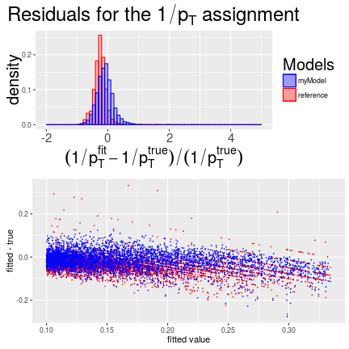

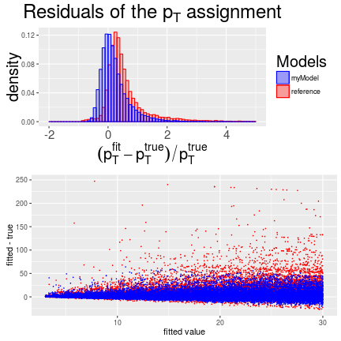

## Other performance metrics: turn-on curves

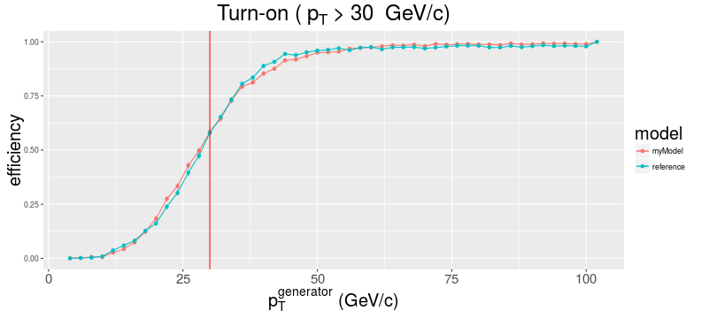

## Summary

Ranking predictors by their importance is an easy job, fitting them in 30 bits is difficult

\[ \Large Backup \]

## 2-3-4 station tracks (mode_inv=14)

| \(\Delta\phi_{2-3}\) | \(\Delta\phi_{2-4}\) | \(\Delta\phi_{3-4}\) | clct2 | clct3 | clct4 |
| --- | --- | --- | --- | --- | --- |
| [6:0] | – | [6:0] | [1:0] | [1:0] | [1:0] |

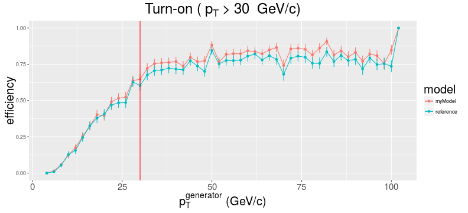

## CLCT Patterns

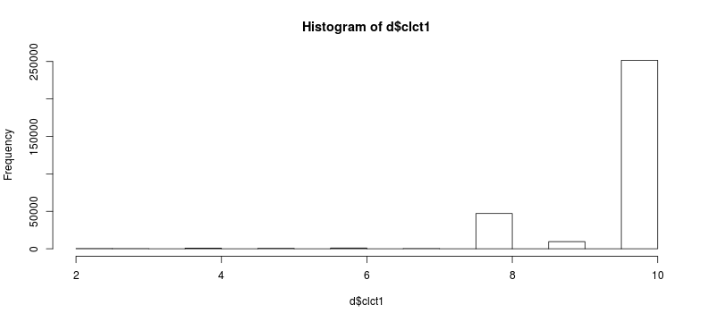